# Statistical Inference & Measures of Effect

Adam La Caze School of Pharmacy The University of Queensland

April 2020

# Introduction

## Objectives

1. Understand the logic of statistical testing in clinical trials
2. Demonstrate an understanding of key statistical concepts: hypothesis testing, $p$ values, confidence intervals and power
3. Be able to describe and interpret common measures of effect used in clinical epidemiology

## Clinical epidemiology

**Bias**

refers to any systematic error in estimating the effect of a drug, exposure or risk factor on a specified outcome

**Random error**

variation that occurs within stochastic processes

## Sources of error

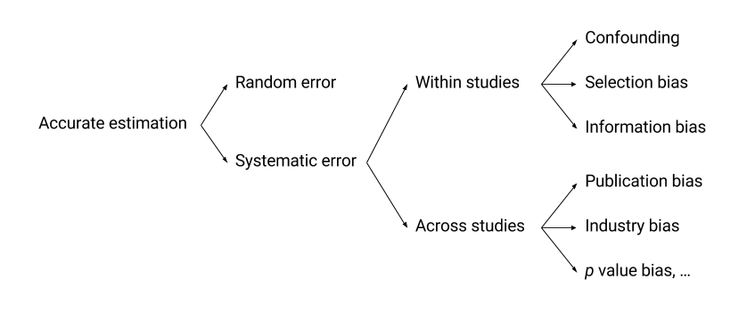

## Task

Focusing on the primary endpoint of the study:

1. Identify the PICO
2. Null hypothesis
3. The statistical result for the study you are assigned

Based on the information available to you, what inference does the study support?

## PICO

| PICO | Notes |
| --- | --- |
| Participants | Who are the participants in the study. What were the inclusion/exclusion criteria? Who participated? |
| Intervention | What is the intervention under investigation? |
| Comparator | What standard treatment is the intervention being tested against? Might be placebo or active control. |
| Outcome | What is the primary endpoint/outcome of the study |

# Logical of statistical inference

1. Understand the logic of statistical testing in clinical trials

## Fair coin

```r
set.seed(123)
ct1 <- rbinom(10, 1, 0.5)
ct1
```

```
##  [1] 0 1 0 1 1 0 1 1 1 0
```

```r
sum_ct1 <- sum(ct1)
```

In this series of tosses, there were 6 $H$ and 4 $T$.

If we run the same code a second time, we get:

```r
set.seed(12)
ct2 <- rbinom(10, 1, 0.5)
ct2
```

```
##  [1] 0 1 1 0 0 0 0 1 0 0
```

```r
sum_ct2 <- sum(ct2)
```

This time we see 3 $H$ and 7 $T$.

## 10 x 10 coin toss experiment

```
##  [1] 5 8 5 5 7 5 7 4 7 4
```

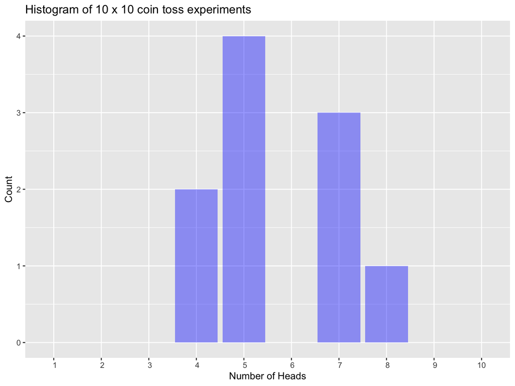

The mean number of $H$ in this series was 5.7.

## 10,000 x 10 coin toss experiment

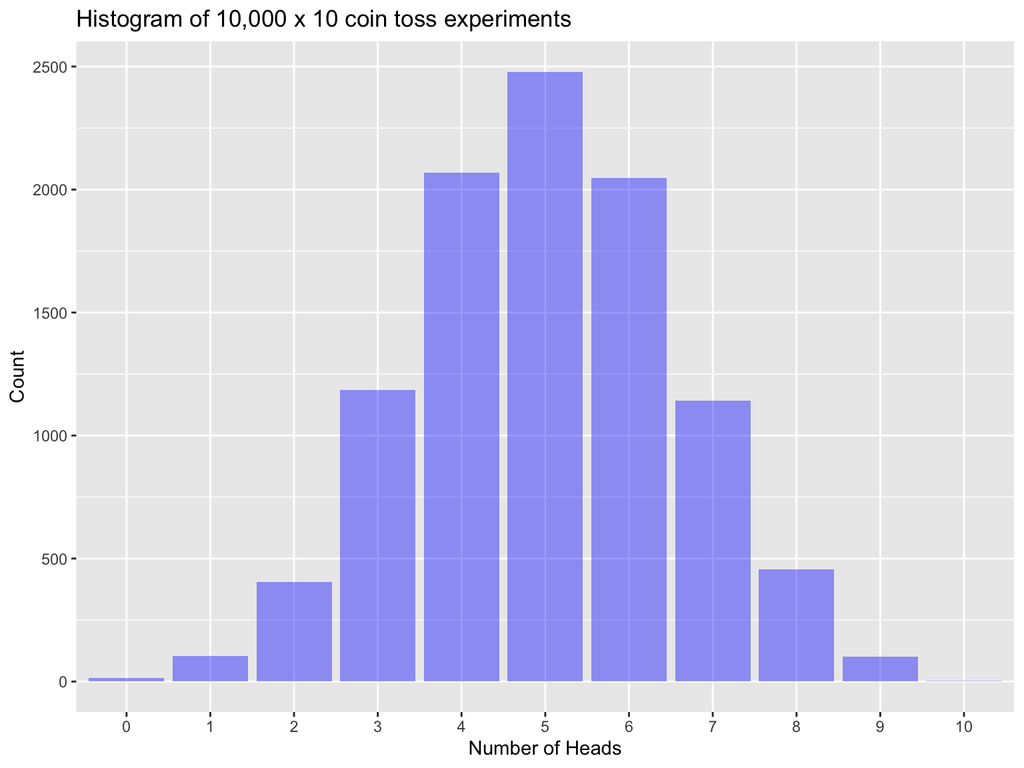

## Task

Imagine you have coin of unknown bias (i.e. the probability of $H$ is unknown—it is unknown whether the coin is fair, favours $T$ or favours $H$). What test could you conduct to assess whether the coin is fair?

Attempt to describe the hypothesis you are testing and the statistical model you are using for the test.

## Coin of unknown bias

1. Consider what outcomes we would expect *if* the coin was fair. This is called the *null hypothesis* and informs the *statistical model*.
2. Use what we know about the statistical model to determine how many repetitions of the 10 coin toss experiment we would need to do for our results to be reliable. This is a consideration of study *power*.
3. Conduct the experiment. Compare the mean *observed* result with what we would expect *if* the coin was fair.
4. If the *observed* mean is considerably larger or smaller than 5, then the study provides evidence that the coin is not fair.
5. The probability of observing a result more extreme than the one we did can be calculated using the statistical model assuming the null hypothesis—this is the *$p$ value*.

## Conduct the experiment

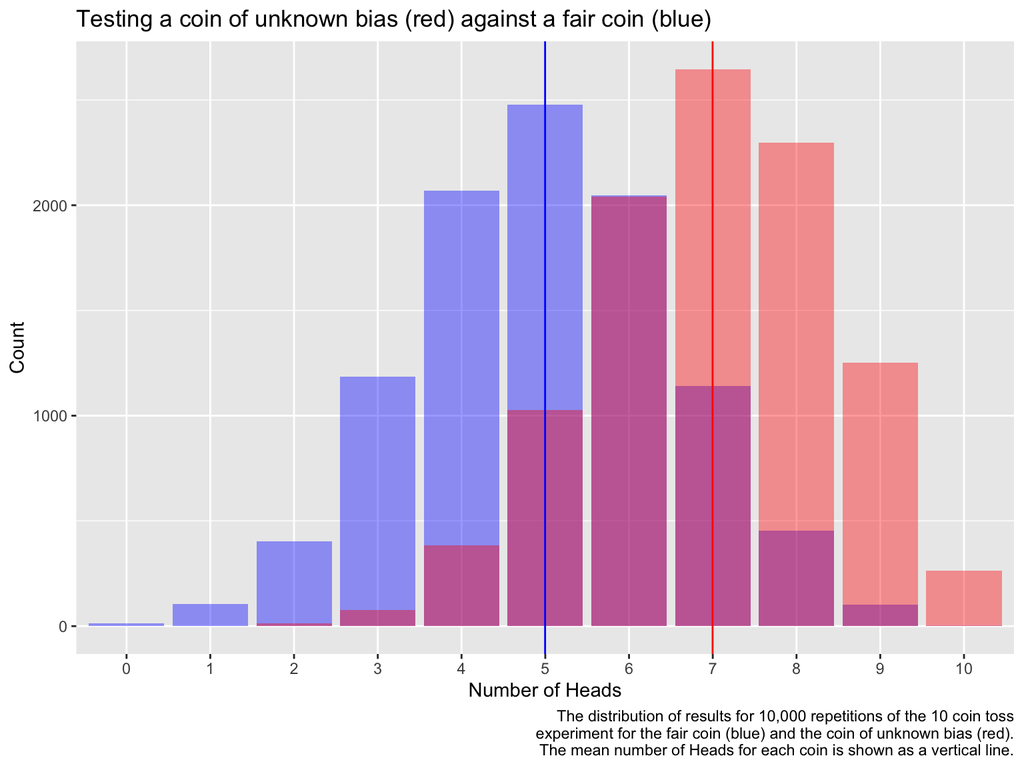

# Key statistical concepts

2. Demonstrate an understanding of key statistical concepts: hypothesis testing, $p$ values, confidence intervals and power

## Important definitions

**Null hypothesis**

the statistical hypothesis that there is no (important) difference between experimental treatment and control in relation to the primary endpoint

**Sampling distribution**

is the distribution of expected results expected assuming a particular hypothesis about the effect size is true (e.g. the null hypothesis), all the assumptions associated with the statistical model are true, and the trial is conducted as planned.

**Type I error ($\alpha$)**

is the pre-test probability of *rejecting* the null hypothesis when the null hypothesis is true. It is usually set at 0.05.

**Type II error ($\beta$)**

$\beta$ is the pre-test probability of *accepting* the null hypothesis when the alternative hypothesis is true.

**Power $(1-\beta)$**

is the pre-study probability that the study will produce a statistically significant result for a given *sample size* and *postulated effect size*

**$p$ value**

a measure of the compatibility of the observed data with the data that would be expected if the null hypothesis was true when all other statistical and methodological assumptions are met

**Confidence interval**

is the range of effect sizes that is considered more compatible with the observed data assuming the statistical and methodological assumptions of the study are met. A 95% confidence interval provides the range of values for which a test of an effect size within the range against the observed data would provide a $p$ value $> 0.05$.

## Hypothesis tests

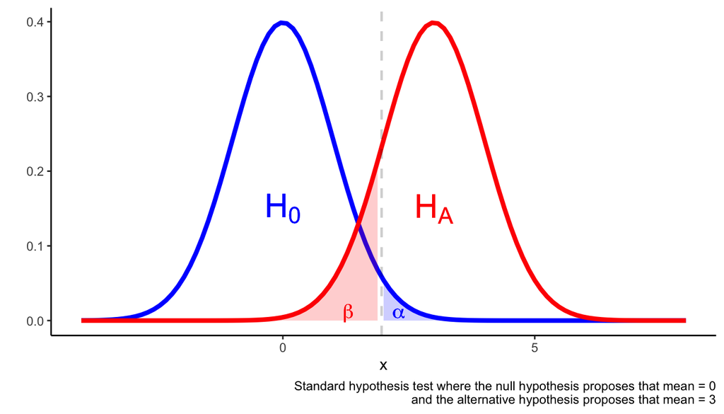

## An overpowered test

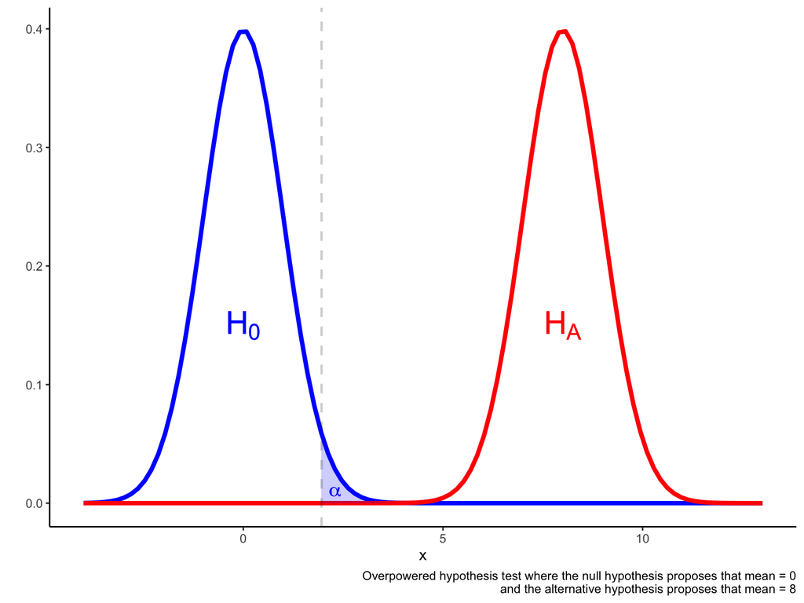

## An underpowered test

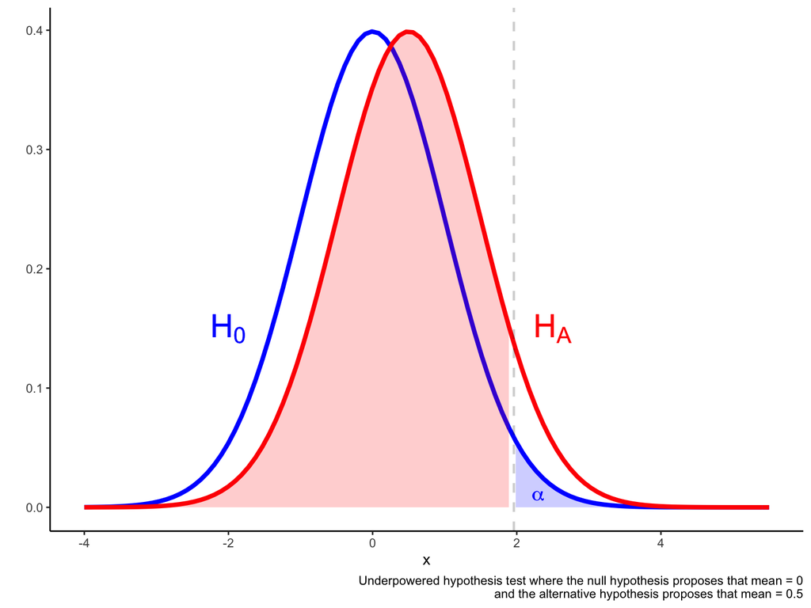

## Take homes

- The most-often used cut-off for $p$ values used in clinical research is 0.05.
- If the $p$ value is $< 0.05$, the result will be considered statistically significant
- A statistically significant result for the *primary endpoint* of a trial is more trustworthy than statistically significant results on secondary endpoints or subgroups—the trial was set up the test the primary endpoint.
- Once you have determined that the primary endpoint of trial was *statistically significant*, the next question is to determine whether the *magnitude* of the effect is *clinically significant*

# Measures of effect

3. Be able to describe and interpret common measures of effect used in clinical epidemiology

## How large is the treatment effect?

A company has developed a new drug that will reduce your relative risk of stroke by 50%

Who is interested?

- You need to take the drug for 10 years
- It will cause an irritating rash in 2% and cause sexual dysfunction in 1%
- Given you are young and healthy, your baseline risk of stroke over the next 10 years is 0.02%

Who is interested?

$$RR = \frac{I_t}{I_c} = 0.01/0.02 = 0.5$$

$$ARR = I_c - I_t = 0.02 - 0.01 = 0.01\%$$

$$NNT = \frac{100}{ARR} = \frac{100}{0.01} = 10000$$

Sexual dysfunction:
$$NNH = \frac{100}{ARI} = \frac{100}{1} = 100$$

## Task

For the empagliflozin paper (EMPA-REG OUTCOMES):

1. Was there an effect on the primary endpoint?
2. If yes, what was the size of the effect on the primary endpoint? Where appropriate present the outcome in terms of
   - hazard ratio,
   - relative risk ratio, relative risk reduction
   - absolute risk reduction
   - number needed to treat

If you have time, have a look at the ertugliflozin paper and the simvastatin paper.